# Build reports to document functions and unit tests

## `flow_doc()`

The `flow_doc()` function provides a way to draw all the functions of a package and store them in an *html* report.

The `pkg` argument can be any package name, from base R, CRAN, or other including your local packages.

The `out` argument must be a path to an *html* file.

If `out` is left `NULL`, the report will be printed to a temporary file and will be opened automatically.

If you don’t provide `pkg` the currently developed package will be considered.

## `flow_test()`

If you’re using the package *{testthat}* for your unit tests, `flow_test()` will help you explore them.

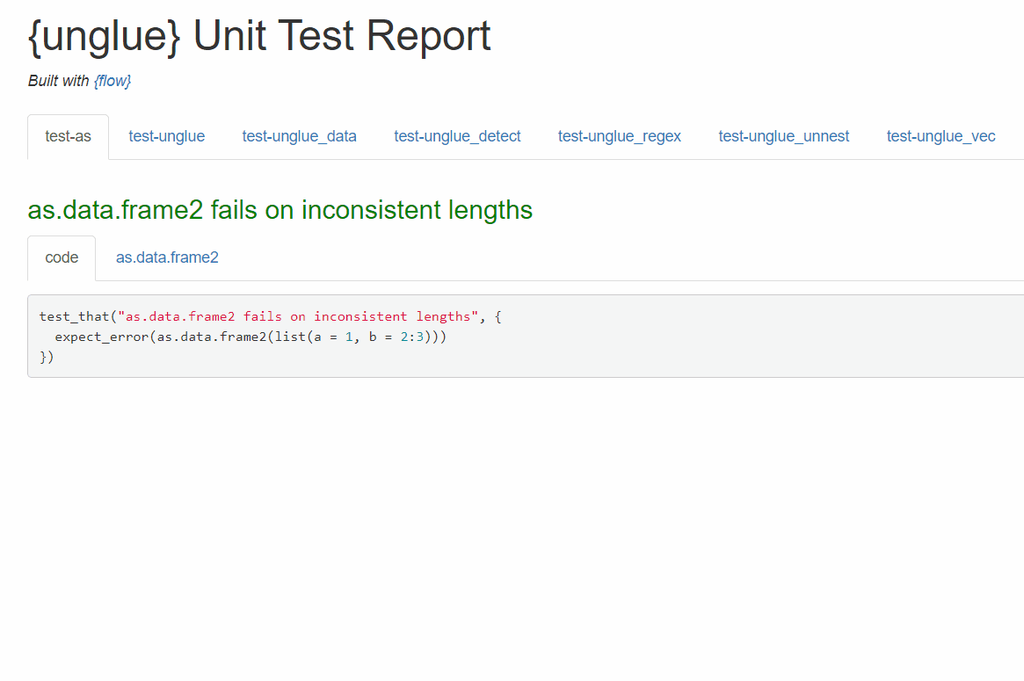

flow_test

Below I ran `flow::flow_test()` after opening the project of my package *{unglue}*.

It built a report with a tab for each test file, then next to the code of each script we’re able to visualize the diagram of our package’s functions and the logical path taken by the code, so we can easily see what was tested and what potentially went wrong.

Successful tests are showed in green, while failed ones (none in the example above) will be shown in red. To show only the failed tests, set the argument `failed_only` to `TRUE`.

If its `out` parameter is left `NULL`, the report will be printed to a temporary file and will be opened automatically.

Other parameters are forwarded to `flow_run()`.